# Analysis of the Restaurant Market in South Mumbai

# *Applied Data Science Capstone*

## Introduction

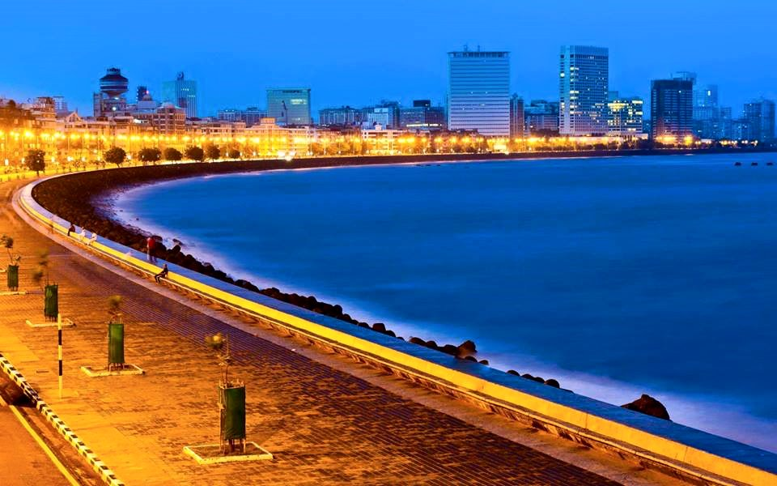

```python
from IPython.display import Image
Image("marinedrive.jpg")
```

Mumbai is the financial, commercial and entertainment capital of India and also one of the world's top ten hubs of commerce in terms of global financial flow. Mumbai's business and investment opportunities, as well as its potential to offer a higher standard of living, attracts migrants not from only India but also from other countries, making the city a multicultural. It is a major hub for world trade, jewelry, finance and banking, film industry, arts, information technology, healthcare, media, entertainment, fashion, tourism etc.

“South Mumbai “is the Mumbai City district which is the southernmost precinct of Greater Mumbai. It extends from Colaba in the south to Mahim and Sion in the north. It comprises the city's main business localities, making it the wealthiest urban precinct in India. But at the same time high business opportunities and development makes South Mumbai as the extremely competitive. In this fierce market, the risk volume is even higher for new start-ups or business enterprises or for making an expansion of business especially for small and medium enterprises.

Due to this, any new business plan or expansion needs to be analyzed carefully. The insight derived from analysis will give better understanding of business environment which help in maneuvering the market.

In a case of Restaurant industry, it is evident that to start a restaurant in right location is very effective and wise strategic plan, but many people especially who haven’t much knowledge and exploration about demographics of South Mumbai are facing many issues to find the suitable restaurant location. Apart from location, many restaurateurs and investors don’t know what kind of restaurant they need to start. Those question are needed to be solved by analysis of the Restaurant Business in South Mumbai.

### 1. Data Section

- importing libraries

```python
!pip install geocoder

from bs4 import BeautifulSoup
import requests
import numpy as np

import pandas as pd
pd.set_option('display.max_columns', None)
pd.set_option('display.max_rows', None)

import json # library to handle JSON files

import urllib
import geocoder


!conda install -c conda-forge geopy --yes # uncomment this line if you haven't completed the Foursquare API lab
from geopy.geocoders import Nominatim # convert an address into latitude and longitude values

import requests # library to handle requests
from pandas.io.json import json_normalize # tranform JSON file into a pandas dataframe

# Matplotlib and associated plotting modules
import matplotlib.cm as cm
import matplotlib.colors as colors

# import k-means from clustering stage
from sklearn.cluster import KMeans

!conda install -c conda-forge folium=0.5.0 --yes # uncomment this line if you haven't completed the Foursquare API lab
import folium # map rendering library

print('Libraries imported.')
```

[output not shown]

[output cut: 15 more lines]

[output not shown]

- Fetching data from CSV file downloaded from Open Government Data (OGD) Platform India (Digital India Initiative)

```python
url = "mumbai_neighbourhoods.csv"
mumbai_data = pd.read_csv(url)
mumbai_data.tail()
```

|  | Neighbourhood | Pincode | officeType | Deliverystatus | regionname | circlename | Taluk | Districtname | statename | Telephone | Related Suboffice | Borough | longitude | latitude |
| --- | --- | --- | --- | --- | --- | --- | --- | --- | --- | --- | --- | --- | --- | --- |
| 1002 | Wada | 421303 | NaN | Delivery | Mumbai | Maharashtra | Wada | Thane | MAHARASHTRA | 02526-271413 | NaN | Palghar | NaN | NaN |
| 1003 | Waki B.O | 401602 | B.O | Delivery | Mumbai | Maharashtra | Dahanu | Thane | MAHARASHTRA | NaN | Dahanu Road | Palghar | NaN | NaN |
| 1004 | Waki B.O | 421303 | B.O | Delivery | Mumbai | Maharashtra | Vikramgad | Thane | MAHARASHTRA | NaN | Wada | Palghar | NaN | NaN |
| 1005 | Zap B.O | 401603 | B.O | Delivery | Mumbai | Maharashtra | Jawhar | Thane | MAHARASHTRA | NaN | Jawhar | Palghar | NaN | NaN |
| 1006 | Zari B.O | 401606 | B.O | Delivery | Mumbai | Maharashtra | Talasari | Thane | MAHARASHTRA | NaN | Talasari | Palghar | NaN | NaN |

- Project is focus on 'South Mumbai' so data filtering as per requirement

```python
mumbai_data = mumbai_data[mumbai_data.Borough=='South Mumbai']
mumbai_data.head()
```

|  | Neighbourhood | Pincode | officeType | Deliverystatus | regionname | circlename | Taluk | Districtname | statename | Telephone | Related Suboffice | Borough | longitude | latitude |
| --- | --- | --- | --- | --- | --- | --- | --- | --- | --- | --- | --- | --- | --- | --- |
| 0 | B.P.Lane | 400003 | NaN | Non-Delivery | Mumbai | Maharashtra | NaN | Mumbai | MAHARASHTRA | 022-23421653 | NaN | South Mumbai | NaN | NaN |
| 1 | BEST STaff Quarters | 400012 | NaN | Non-Delivery | Mumbai | Maharashtra | NaN | Mumbai | MAHARASHTRA | 022-24180776 | NaN | South Mumbai | NaN | NaN |
| 2 | Chamarbaug | 400012 | NaN | Non-Delivery | Mumbai | Maharashtra | Mumbai | Mumbai | MAHARASHTRA | 022-24705407 | NaN | South Mumbai | NaN | NaN |
| 3 | Chinchbunder | 400009 | NaN | Delivery | Mumbai | Maharashtra | NaN | Mumbai | MAHARASHTRA | 022-23771116 | NaN | South Mumbai | NaN | NaN |
| 4 | Cotton Exchange | 400033 | NaN | Non-Delivery | Mumbai | Maharashtra | Mumbai | Mumbai | MAHARASHTRA | 022-23742035 | NaN | South Mumbai | NaN | NaN |

- Data cleaning as removing redundancy and unwanted duplicity

1.Join all the AreaName by Pincode

```python
def neighbourhood_list(grouped):
    return ', '.join(sorted(grouped['Neighbourhood'].tolist()))

grp = mumbai_data.groupby(['Pincode', 'Borough'])
south_mumbai_data = grp.apply(neighbourhood_list).reset_index(name='Neighbourhood')
```

2.Displaying south_mumbai_data

```python
south_mumbai_data.head()
```

|  | Pincode | Borough | Neighbourhood |
| --- | --- | --- | --- |
| 0 | 400001 | South Mumbai | Bazargate , CSMT , M.P.T. , Stock Exchange , T... |
| 1 | 400002 | South Mumbai | Kalbadevi , Ramwadi , S. C. Court , Thakurdwar |
| 2 | 400003 | South Mumbai | B.P.Lane , Mandvi (Mumbai), Masjid , Null Bazar |
| 3 | 400004 | South Mumbai | Ambewadi (Mumbai), Charni Road , Chaupati , G... |
| 4 | 400005 | South Mumbai | Asvini , Colaba , Colaba Bazar , Holiday Camp ... |

3.Getting Coordinates as per pincode

```python
def get_latlng(postal_code):
    # initialize your variable to None
    lat_lng_coords = None
    # loop until you get the coordinates
    while(lat_lng_coords is None):
        g = geocoder.arcgis('{}, Mumbai, Maharashtra'.format(postal_code))
        lat_lng_coords = g.latlng
    return lat_lng_coords
```

e.g, For Pincode 400001

```python
get_latlng('400001')
```

```
[18.938919252000062, 72.83747000000005]
```

Now appling this functions for all pincode of areas of South Mumbai

```python
latitude = []
longitude = []
for row in south_mumbai_data['Pincode']:
    coordinate = get_latlng(row)
    latitude.append(coordinate[0])
    longitude.append(coordinate[1])

south_mumbai_data['Latitude']=latitude
south_mumbai_data['Longitude']=longitude
south_mumbai_data.head()
```

|  | Pincode | Borough | Neighbourhood | Latitude | Longitude |
| --- | --- | --- | --- | --- | --- |
| 0 | 400001 | South Mumbai | Bazargate , CSMT , M.P.T. , Stock Exchange , T... | 18.938919 | 72.837470 |
| 1 | 400002 | South Mumbai | Kalbadevi , Ramwadi , S. C. Court , Thakurdwar | 18.947760 | 72.826815 |
| 2 | 400003 | South Mumbai | B.P.Lane , Mandvi (Mumbai), Masjid , Null Bazar | 18.951733 | 72.835129 |
| 3 | 400004 | South Mumbai | Ambewadi (Mumbai), Charni Road , Chaupati , G... | 18.955285 | 72.820930 |
| 4 | 400005 | South Mumbai | Asvini , Colaba , Colaba Bazar , Holiday Camp ... | 18.904399 | 72.810195 |

- Loading property data which are researched from different Indian propert portals and property news and professional realtors which stored in CSV file

```python
property_url = 'South_Mumbai_Real_Estate.csv'
property_data = pd.read_csv(property_url)
property_data.head()
```

|  | Pincode | Neighbourhood | Avg. Price Range (Rs. per sq. ft.) |
| --- | --- | --- | --- |
| 0 | 400001 | Bazargate , CSMT , M.P.T. , Stock Exchange , T... | 68817.0 |
| 1 | 400002 | Kalbadevi , Ramwadi , S. C. Court , Thakurdwar | 49502.0 |
| 2 | 400003 | B.P.Lane , Mandvi (Mumbai), Masjid , Null Bazar | 16666.0 |
| 3 | 400004 | Ambewadi (Mumbai), Charni Road , Chaupati , G... | 32926.0 |
| 4 | 400005 | Asvini , Colaba , Colaba Bazar , Holiday Camp ... | 68817.0 |

- South Mumbai ward wise average property price

```python
southmumbai_propertyrate = 'BMCWardproperties.csv'
southmumbai_propertyrate_data = pd.read_csv(southmumbai_propertyrate)
southmumbai_propertyrate_data.head()
```

|  | Ward | Avg Price |
| --- | --- | --- |
| 0 | A | 125761 |
| 1 | B | 45900 |
| 2 | C | 65800 |
| 3 | D | 105753 |
| 4 | E | 55800 |

- Fetching details from wikipedia page of Administrative divisions of Mumbai 1.Fetch data from wikipedia

```python
# fetching data from wikipedia page and storing into m_wiki_data
url = "https://en.wikipedia.org/wiki/Administrative_divisions_of_Mumbai"
m_wiki_data = requests.get(url).text
interm = m_wiki_data[m_wiki_data.find("<table"):m_wiki_data.find("</table>")+8]
population_sm = pd.read_html(interm, header = 0)[0]
population_sm.head()
```

|  | Ward | Population |
| --- | --- | --- |
| 0 | A | 210926 |
| 1 | B | 140480 |
| 2 | C | 190670 |
| 3 | D | 378610 |
| 4 | E | 439390 |

- Next, we are going to start utilizing the Foursquare API to explore the South Mumbabi for data collection

```python
CLIENT_ID = 'XXXXXX' # your Foursquare ID
CLIENT_SECRET = 'XXXX' # your Foursquare Secret
VERSION = '20180605' # Foursquare API version

print('Your credentails:')
print('CLIENT_ID: ' + CLIENT_ID)
print('CLIENT_SECRET:' + CLIENT_SECRET)
```

```
Your credentails:
CLIENT_ID: XXXXXX
CLIENT_SECRET:XXXX
```

1.Taking first area of South Mumbai and creating url

```python
first_lat = south_mumbai_data['Latitude'][0]
first_long = south_mumbai_data['Longitude'][0]
radius = 500
LIMIT = 100
url = 'https://api.foursquare.com/v2/venues/explore?&client_id={}&client_secret={}&v={}&ll={},{}&radius={}&limit={}'.format(
    CLIENT_ID,
    CLIENT_SECRET,
    VERSION,
    first_lat,
    first_long,
    radius,
    LIMIT)
```

2.Getting results

```python
results = requests.get(url).json()
```

```python
# function that extracts the category of the venue
def get_category_type(row):
    try:
        categories_list = row['categories']
    except:
        categories_list = row['venue.categories']

    if len(categories_list) == 0:
        return None
    else:
        return categories_list[0]['name']
```

3.Now we are ready to clean the json and structure it into a *pandas* dataframe.

```python
venues = results['response']['groups'][0]['items']

nearby_venues = json_normalize(venues) # flatten JSON

# filter columns
filtered_columns = ['venue.name', 'venue.categories', 'venue.location.lat', 'venue.location.lng']
nearby_venues =nearby_venues.loc[:, filtered_columns]

# filter the category for each row
nearby_venues['venue.categories'] = nearby_venues.apply(get_category_type, axis=1)

# clean columns
nearby_venues.columns = [col.split(".")[-1] for col in nearby_venues.columns]

nearby_venues.head()
```

|  | name | categories | lat | lng |
| --- | --- | --- | --- | --- |
| 0 | Sher-E-Punjab | Indian Restaurant | 18.937944 | 72.837853 |
| 1 | Chhatrapati Shivaji Maharaj Terminus | Train Station | 18.940297 | 72.835384 |
| 2 | Royal China | Chinese Restaurant | 18.938715 | 72.832933 |
| 3 | Dakshin Bar And Kitchen | Seafood Restaurant | 18.936489 | 72.837490 |
| 4 | Town House Cafe | Bar | 18.938550 | 72.833464 |

### 2. Methodology section

- Creating South Mumbai Map

```python
address = 'Mumbai, Maharashtra'

geolocator = Nominatim(user_agent="userid")
location = geolocator.geocode(address)
latitude = location.latitude
longitude = location.longitude


# create map of South Mumbai using latitude and longitude values
map_south_mumbai = folium.Map(location=[latitude, longitude], zoom_start=11.5)

# add markers to map
for lat, lng, borough, neighborhood in zip(south_mumbai_data['Latitude'], south_mumbai_data['Longitude'], south_mumbai_data['Borough'], south_mumbai_data['Neighbourhood']):
    label = '{}, {}'.format(neighborhood, borough)
    label = folium.Popup(label, parse_html=True)
    folium.CircleMarker(
        [lat, lng],
        radius=5,
        popup=label,
        color='red',
        fill=True,
        fill_color='#cc3139',
        fill_opacity=0.7,
        parse_html=False).add_to(map_south_mumbai)

map_south_mumbai
```

[interactive chart not shown]

- Choropleth Maps of Properties of South Mumbai

```python
#South Mumbai Coordinates
SM_COORDINATES = (18.96, 72.82)

southmumbai_geo = r'southmumbai.geojson'


# create empty map zoomed in on South Mumbai
map = folium.Map(location=SM_COORDINATES,tiles="Mapbox Bright", zoom_start=11)

# creation of the choropleth
map_sc = folium.Map(location=SM_COORDINATES,tiles="Mapbox Bright", zoom_start=11)


map_sc.choropleth(geo_data = southmumbai_geo,
              name='choropleth',
              data = southmumbai_propertyrate_data,
              columns = ['Ward', 'Avg Price'],
              key_on = 'feature.properties.Ward',
              fill_color = 'YlOrRd',
              fill_opacity = 0.7,
              line_opacity = 0.2,
              legend_name = 'Property Rate in South Mumbai (Rs. per sq. ft.)')

display(map_sc)
```

[interactive chart not shown]

- Choropleth Maps of Population of South Mumbai

```python
#South Mumbai Coordinates
SM_COORDINATES = (18.96, 72.82)

southmumbai_geo = r'southmumbai.geojson'


# create empty map zoomed in on South Mumbai
map = folium.Map(location=SM_COORDINATES,tiles="Mapbox Bright", zoom_start=11)

# creation of the choropleth
map_sc = folium.Map(location=SM_COORDINATES,tiles="Mapbox Bright", zoom_start=11)


map_sc.choropleth(geo_data = southmumbai_geo,
              name='choropleth',
              data = population_sm,
              columns = ['Ward', 'Population'],
              key_on = 'feature.properties.Ward',
              fill_color = 'YlOrRd',
              fill_opacity = 0.7,
              line_opacity = 0.2,
              legend_name = 'Population in areas of South Mumbai')

display(map_sc)
```

[interactive chart not shown]

- Finding the number of restaurants by the areas of South Mumbai

```python
def getNearbyVenues(names, latitudes, longitudes, radius=500):

    venues_list=[]
    for name, lat, lng in zip(names, latitudes, longitudes):
        print(name)

        # create the API request URL
        url = 'https://api.foursquare.com/v2/venues/explore?&client_id={}&client_secret={}&v={}&ll={},{}&radius={}&limit={}'.format(
            CLIENT_ID,
            CLIENT_SECRET,
            VERSION,
            lat,
            lng,
            radius,
            LIMIT)

        # make the GET request
        results = requests.get(url).json()["response"]['groups'][0]['items']

        # return only relevant information for each nearby venue
        venues_list.append([(
            name,
            lat,
            lng,
            v['venue']['name'],
            v['venue']['location']['lat'],
            v['venue']['location']['lng'],
            v['venue']['categories'][0]['name']) for v in results])

    nearby_venues = pd.DataFrame([item for venue_list in venues_list for item in venue_list])
    nearby_venues.columns = ['Neighbourhood',
                  'Neighbourhood Latitude',
                  'Neighbourhood Longitude',
                  'Venue',
                  'Venue Latitude',
                  'Venue Longitude',
                  'Venue Category']

    return(nearby_venues)
```

```python
southmumbai_venues = getNearbyVenues(names=south_mumbai_data['Neighbourhood'],
                                   latitudes=south_mumbai_data['Latitude'],
                                   longitudes=south_mumbai_data['Longitude']
                                  )
```

```
Bazargate , CSMT , M.P.T. , Stock Exchange , Tajmahal , Town Hall  (Mumbai)
Kalbadevi , Ramwadi , S. C. Court , Thakurdwar
B.P.Lane , Mandvi  (Mumbai), Masjid , Null Bazar
Ambewadi  (Mumbai), Charni Road , Chaupati , Girgaon , Madhavbaug , Opera House
Asvini , Colaba , Colaba Bazar , Holiday Camp , V.W.T.C.
Malabar Hill
Bharat Nagar  (Mumbai), Grant Road , N.S.Patkar Marg , S V Marg , Tardeo
Falkland Road , J.J.Hospital , Kamathipura , M A Marg , Mumbai Central
Chinchbunder , Noor Baug , Princess Dock
Dockyard Road , Mazgaon , Mazgaon Dock , Mazgaon Road , V K Bhavan
Agripada , BPC  Jacob Circle , Chinchpokli , Haines Road , Jacob Circle
BEST STaff Quarters , Chamarbaug , Haffkin Institute , Lal Baug , Parel , Parel Naka , Parel Rly Work Shop
Dadar , Dadar Colony , Naigaon  (Mumbai)
Sewri
Worli , Worli Naka
Central Building , Churchgate , Marine Lines
Nariman Point , New Yogakshema
Chunabhatti , Raoli Camp , Sion , Transit Camp
New Prabhadevi Road , Prabhadevi
Cumballa Hill , Cumballa Sea Face , Dr Deshmukh Marg , Gowalia Tank
V J B Udyan
Ranade Road , S V S Marg , Shivaji Park  (Mumbai)
Worli Colony , Worli Police Camp , Worli Sea Face
Kidwai Nagar  (Mumbai), Wadala , Wadala Rs
High Court Building  (Mumbai), Mantralaya  (Mumbai), Secretariate
Cotton Exchange , Kalachowki , L B S N E collage , Reay Road , Tank Road
Haji Ali , Tulsiwadi
Rajbhavan  (Mumbai)
Antop Hill , B P T Colony , C G S Colony , Wadala Truck Terminal
Sakinaka , Vihar Road
```

### 'Top 5 regions of South Mumbai with Highest Number of Restaurants'

```python
areawise_veneus = southmumbai_venues.groupby('Neighbourhood').count()
areawise_veneus.to_csv('South_Mumbai_Restaurants_Count.cvs',index=False)
areawise_veneus.sort_values(by=['Venue'],ascending=False).head()
```

| Neighbourhood | Neighbourhood Latitude | Neighbourhood Longitude | Venue | Venue Latitude | Venue Longitude | Venue Category |
| --- | --- | --- | --- | --- | --- | --- |
| High Court Building (Mumbai), Mantralaya (Mumbai), Secretariate | 74 | 74 | 74 | 74 | 74 | 74 |
| Central Building , Churchgate , Marine Lines | 50 | 50 | 50 | 50 | 50 | 50 |
| Nariman Point , New Yogakshema | 36 | 36 | 36 | 36 | 36 | 36 |
| Cumballa Hill , Cumballa Sea Face , Dr Deshmukh Marg , Gowalia Tank | 23 | 23 | 23 | 23 | 23 | 23 |
| Ambewadi (Mumbai), Charni Road , Chaupati , Girgaon , Madhavbaug , Opera House | 20 | 20 | 20 | 20 | 20 | 20 |

### Top 5 regions of South Mumbai with Lowest Number of Restaurants'

```python
areawise_veneus.sort_values(by=['Venue']).head()
```

| Neighbourhood | Neighbourhood Latitude | Neighbourhood Longitude | Venue | Venue Latitude | Venue Longitude | Venue Category |
| --- | --- | --- | --- | --- | --- | --- |
| Antop Hill , B P T Colony , C G S Colony , Wadala Truck Terminal | 2 | 2 | 2 | 2 | 2 | 2 |
| Chunabhatti , Raoli Camp , Sion , Transit Camp | 3 | 3 | 3 | 3 | 3 | 3 |
| Dockyard Road , Mazgaon , Mazgaon Dock , Mazgaon Road , V K Bhavan | 4 | 4 | 4 | 4 | 4 | 4 |
| Cotton Exchange , Kalachowki , L B S N E collage , Reay Road , Tank Road | 4 | 4 | 4 | 4 | 4 | 4 |
| Chinchbunder , Noor Baug , Princess Dock | 4 | 4 | 4 | 4 | 4 | 4 |

#### Let's find out how many unique category of restaurants from South Mumbai

```python
print('There are {} uniques categories.'.format(len(areawise_veneus['Venue Category'].unique())))
```

```
There are 17 uniques categories.
```

```python
def getNearbyVenuesNames(names, latitudes, longitudes, radius=500):

    venues_list=[]
    for name, lat, lng in zip(names, latitudes, longitudes):


        # create the API request URL
        url = 'https://api.foursquare.com/v2/venues/explore?&client_id={}&client_secret={}&v={}&ll={},{}&radius={}&limit={}'.format(
            CLIENT_ID,
            CLIENT_SECRET,
            VERSION,
            lat,
            lng,
            radius,
            LIMIT)

        # make the GET request
        results = requests.get(url).json()["response"]['groups'][0]['items']

        # return only relevant information for each nearby venue
        venues_list.append([(

            v['venue']['name']
            ) for v in results])



    return(venues_list)
```

```python
southmumbai_rest = getNearbyVenuesNames(names=south_mumbai_data['Neighbourhood'],
                                   latitudes=south_mumbai_data['Latitude'],
                                   longitudes=south_mumbai_data['Longitude']
                                  )
southmumbai_rest
```

[output not shown]

```python
change=[]
for i in range(0, len(southmumbai_rest)-1):
  change = change + southmumbai_rest[i]
```

### Top of 5 QSR Franchises in South Mumbai

```python
df = pd.DataFrame({'col':change})
df['col'].value_counts().head()
```

```
Cafe Coffee Day       13
Subway                 8
Domino's Pizza         5
McDonald's             3
Monginis Cake Shop     3
Name: col, dtype: int64
```

```python
def getNearbyVenuesCat(names, latitudes, longitudes, radius=500):

    venues_list=[]
    for name, lat, lng in zip(names, latitudes, longitudes):


        # create the API request URL
        url = 'https://api.foursquare.com/v2/venues/explore?&client_id={}&client_secret={}&v={}&ll={},{}&radius={}&limit={}'.format(
            CLIENT_ID,
            CLIENT_SECRET,
            VERSION,
            lat,
            lng,
            radius,
            LIMIT)

        # make the GET request
        results = requests.get(url).json()["response"]['groups'][0]['items']

        # return only relevant information for each nearby venue
        venues_list.append([(

            v['venue']['categories'][0]['name']
            ) for v in results])



    return(venues_list)
```

```python
southmumbai_rest_cat = getNearbyVenuesCat(names=south_mumbai_data['Neighbourhood'],
                                   latitudes=south_mumbai_data['Latitude'],
                                   longitudes=south_mumbai_data['Longitude']
                                  )
```

```python
totalcat=[]
for i in range(0, len(southmumbai_rest_cat)-1):
  totalcat = totalcat + southmumbai_rest_cat[i]
```

### Top 5 type of Restaurant of service types

```python
dfcat = pd.DataFrame({'col':totalcat})
dfcat['col'].value_counts().head(5)
```

```
Indian Restaurant       47
Café                    29
Fast Food Restaurant    20
Chinese Restaurant      17
Bakery                  15
Name: col, dtype: int64
```

```python
southmumbai_ves = getNearbyVenues(names=south_mumbai_data['Neighbourhood'],
                                   latitudes=south_mumbai_data['Latitude'],
                                   longitudes=south_mumbai_data['Longitude']
                                  )
```

```python
southmumbai_ves.groupby('Neighbourhood').count()
```

| Neighbourhood | Neighbourhood Latitude | Neighbourhood Longitude | Venue | Venue Latitude | Venue Longitude | Venue Category |
| --- | --- | --- | --- | --- | --- | --- |
| Agripada , BPC Jacob Circle , Chinchpokli , Haines Road , Jacob Circle | 6 | 6 | 6 | 6 | 6 | 6 |
| Ambewadi (Mumbai), Charni Road , Chaupati , Girgaon , Madhavbaug , Opera House | 20 | 20 | 20 | 20 | 20 | 20 |
| Antop Hill , B P T Colony , C G S Colony , Wadala Truck Terminal | 2 | 2 | 2 | 2 | 2 | 2 |
| Asvini , Colaba , Colaba Bazar , Holiday Camp , V.W.T.C. | 5 | 5 | 5 | 5 | 5 | 5 |
| B.P.Lane , Mandvi (Mumbai), Masjid , Null Bazar | 19 | 19 | 19 | 19 | 19 | 19 |
| BEST STaff Quarters , Chamarbaug , Haffkin Institute , Lal Baug , Parel , Parel Naka , Parel Rly Work Shop | 13 | 13 | 13 | 13 | 13 | 13 |
| Bazargate , CSMT , M.P.T. , Stock Exchange , Tajmahal , Town Hall (Mumbai) | 19 | 19 | 19 | 19 | 19 | 19 |
| Bharat Nagar (Mumbai), Grant Road , N.S.Patkar Marg , S V Marg , Tardeo | 11 | 11 | 11 | 11 | 11 | 11 |
| Central Building , Churchgate , Marine Lines | 50 | 50 | 50 | 50 | 50 | 50 |
| Chinchbunder , Noor Baug , Princess Dock | 4 | 4 | 4 | 4 | 4 | 4 |
| Chunabhatti , Raoli Camp , Sion , Transit Camp | 3 | 3 | 3 | 3 | 3 | 3 |
| Cotton Exchange , Kalachowki , L B S N E collage , Reay Road , Tank Road | 4 | 4 | 4 | 4 | 4 | 4 |
| Cumballa Hill , Cumballa Sea Face , Dr Deshmukh Marg , Gowalia Tank | 23 | 23 | 23 | 23 | 23 | 23 |
| Dadar , Dadar Colony , Naigaon (Mumbai) | 19 | 19 | 19 | 19 | 19 | 19 |
| Dockyard Road , Mazgaon , Mazgaon Dock , Mazgaon Road , V K Bhavan | 4 | 4 | 4 | 4 | 4 | 4 |
| Falkland Road , J.J.Hospital , Kamathipura , M A Marg , Mumbai Central | 9 | 9 | 9 | 9 | 9 | 9 |
| Haji Ali , Tulsiwadi | 11 | 11 | 11 | 11 | 11 | 11 |
| High Court Building (Mumbai), Mantralaya (Mumbai), Secretariate | 74 | 74 | 74 | 74 | 74 | 74 |
| Kalbadevi , Ramwadi , S. C. Court , Thakurdwar | 9 | 9 | 9 | 9 | 9 | 9 |
| Kidwai Nagar (Mumbai), Wadala , Wadala Rs | 10 | 10 | 10 | 10 | 10 | 10 |
| Malabar Hill | 5 | 5 | 5 | 5 | 5 | 5 |
| Nariman Point , New Yogakshema | 36 | 36 | 36 | 36 | 36 | 36 |
| New Prabhadevi Road , Prabhadevi | 16 | 16 | 16 | 16 | 16 | 16 |
| Ranade Road , S V S Marg , Shivaji Park (Mumbai) | 9 | 9 | 9 | 9 | 9 | 9 |
| Sakinaka , Vihar Road | 6 | 6 | 6 | 6 | 6 | 6 |
| V J B Udyan | 8 | 8 | 8 | 8 | 8 | 8 |
| Worli , Worli Naka | 19 | 19 | 19 | 19 | 19 | 19 |
| Worli Colony , Worli Police Camp , Worli Sea Face | 5 | 5 | 5 | 5 | 5 | 5 |

```python
# one hot encoding
sm_onehot = pd.get_dummies(southmumbai_ves[['Venue Category']], prefix="", prefix_sep="")

# add neighborhood column back to dataframe
sm_onehot['Neighbourhood'] = southmumbai_ves['Neighbourhood']

# move neighborhood column to the first column
fixed_columns = [sm_onehot.columns[-1]] + list(sm_onehot.columns[:-1])
sm_onehot = sm_onehot[fixed_columns]

sm_grouped = sm_onehot.groupby('Neighbourhood').mean().reset_index()
```

```python
def return_most_common_venues(row, num_top_venues):
    row_categories = row.iloc[1:]
    row_categories_sorted = row_categories.sort_values(ascending=False)

    return row_categories_sorted.index.values[0:num_top_venues]
```

```python
num_top_venues = 20

indicators = ['st', 'nd', 'rd']

# create columns according to number of top venues
columns = ['Neighbourhood']
for ind in np.arange(num_top_venues):
    try:
        columns.append('{}{} Most Common Venue'.format(ind+1, indicators[ind]))
    except:
        columns.append('{}th Most Common Venue'.format(ind+1))

# create a new dataframe
neighbourhoods_venues_sorted = pd.DataFrame(columns=columns)
neighbourhoods_venues_sorted['Neighbourhood'] = sm_grouped['Neighbourhood']

for ind in np.arange(sm_grouped.shape[0]):
    neighbourhoods_venues_sorted.iloc[ind, 1:] = return_most_common_venues(sm_grouped.iloc[ind, :], num_top_venues)

neighbourhoods_venues_sorted
```

|  | Neighbourhood | 1st Most Common Venue | 2nd Most Common Venue | 3rd Most Common Venue | 4th Most Common Venue | 5th Most Common Venue | 6th Most Common Venue | 7th Most Common Venue | 8th Most Common Venue | 9th Most Common Venue | 10th Most Common Venue | 11th Most Common Venue | 12th Most Common Venue | 13th Most Common Venue | 14th Most Common Venue | 15th Most Common Venue | 16th Most Common Venue | 17th Most Common Venue | 18th Most Common Venue | 19th Most Common Venue | 20th Most Common Venue |
| --- | --- | --- | --- | --- | --- | --- | --- | --- | --- | --- | --- | --- | --- | --- | --- | --- | --- | --- | --- | --- | --- |
| 0 | Agripada , BPC Jacob Circle , Chinchpokli , H... | Gym | Restaurant | Coffee Shop | Indian Restaurant | Racetrack | Tea Room | Zoo | Donut Shop | Farmers Market | Electronics Store | Dessert Shop | Diner | Field | Department Store | Deli / Bodega | Dance Studio | Fast Food Restaurant | Food | Flea Market | Cricket Ground |
| 1 | Ambewadi (Mumbai), Charni Road , Chaupati , G... | Indian Restaurant | Train Station | Juice Bar | Pizza Place | Snack Place | Italian Restaurant | Café | Restaurant | Sandwich Place | Breakfast Spot | Indie Movie Theater | Fast Food Restaurant | Coffee Shop | Music Venue | Vegetarian / Vegan Restaurant | Gym / Fitness Center | Farmers Market | Donut Shop | Electronics Store | Diner |
| 2 | Antop Hill , B P T Colony , C G S Colony , Wad... | Smoke Shop | Gym / Fitness Center | Food | Dance Studio | Deli / Bodega | Department Store | Dessert Shop | Diner | Donut Shop | Electronics Store | Farmers Market | Fast Food Restaurant | Field | Flea Market | Zoo | Cricket Ground | Food Truck | French Restaurant | Fried Chicken Joint | Furniture / Home Store |
| 3 | Asvini , Colaba , Colaba Bazar , Holiday Camp ... | Cricket Ground | Gym | Indian Restaurant | Bakery | Garden | Food | Deli / Bodega | Department Store | Dessert Shop | Diner | Donut Shop | Electronics Store | Farmers Market | Fast Food Restaurant | Field | Flea Market | French Restaurant | Food Truck | Cupcake Shop | Fried Chicken Joint |
| 4 | B.P.Lane , Mandvi (Mumbai), Masjid , Null Bazar | Indian Restaurant | American Restaurant | Market | Dessert Shop | Convenience Store | Electronics Store | Middle Eastern Restaurant | Chinese Restaurant | Rest Area | Restaurant | Café | BBQ Joint | Indian Sweet Shop | Furniture / Home Store | General Entertainment | Gym | Diner | Grocery Store | Donut Shop | Golf Course |
| 5 | BEST STaff Quarters , Chamarbaug , Haffkin Ins... | Indian Restaurant | Chinese Restaurant | Playground | Bus Station | Restaurant | Sporting Goods Shop | Coffee Shop | Hotel | Diner | Field | Dessert Shop | Donut Shop | Electronics Store | Department Store | Farmers Market | Deli / Bodega | Fast Food Restaurant | Zoo | Flea Market | Cupcake Shop |
| 6 | Bazargate , CSMT , M.P.T. , Stock Exchange , T... | Indian Restaurant | Café | Irani Cafe | Seafood Restaurant | Fast Food Restaurant | Lounge | Clothing Store | Chinese Restaurant | Sandwich Place | Food Truck | Multiplex | Bar | Hotel | Hostel | Train Station | Asian Restaurant | Furniture / Home Store | General Entertainment | Department Store | Dessert Shop |
| 7 | Bharat Nagar (Mumbai), Grant Road , N.S.Patka... | Electronics Store | Nightclub | Hotel | Fast Food Restaurant | Chinese Restaurant | Snack Place | Bakery | Lounge | Train Station | Vegetarian / Vegan Restaurant | Field | Diner | Donut Shop | Department Store | Deli / Bodega | Farmers Market | Dance Studio | Dessert Shop | Zoo | Flea Market |
| 8 | Central Building , Churchgate , Marine Lines | Fast Food Restaurant | Ice Cream Shop | Indian Restaurant | Café | Cricket Ground | Hotel | Italian Restaurant | Movie Theater | Train Station | Bakery | Coffee Shop | Chinese Restaurant | Pizza Place | Gastropub | College Academic Building | Other Great Outdoors | General Entertainment | Japanese Restaurant | Motel | Donut Shop |
| 9 | Chinchbunder , Noor Baug , Princess Dock | Harbor / Marina | Indian Restaurant | Boat or Ferry | Furniture / Home Store | Zoo | Food | Deli / Bodega | Department Store | Dessert Shop | Diner | Donut Shop | Electronics Store | Farmers Market | Fast Food Restaurant | Field | Flea Market | French Restaurant | Food Truck | Cupcake Shop | Fried Chicken Joint |
| 10 | Chunabhatti , Raoli Camp , Sion , Transit Camp | Dance Studio | Mountain | Seafood Restaurant | Zoo | Flea Market | Deli / Bodega | Department Store | Dessert Shop | Diner | Donut Shop | Electronics Store | Farmers Market | Fast Food Restaurant | Field | Food | Cricket Ground | Food Truck | French Restaurant | Fried Chicken Joint | Furniture / Home Store |
| 11 | Cotton Exchange , Kalachowki , L B S N E colla... | Hookah Bar | Whisky Bar | Bakery | Plaza | Food | Dance Studio | Deli / Bodega | Department Store | Dessert Shop | Diner | Donut Shop | Electronics Store | Farmers Market | Fast Food Restaurant | Field | Flea Market | Food Truck | Cricket Ground | French Restaurant | Fried Chicken Joint |
| 12 | Cumballa Hill , Cumballa Sea Face , Dr Deshmuk... | Sandwich Place | Bar | Bakery | Pizza Place | Park | Other Great Outdoors | Food Truck | Lounge | Hotel | Chinese Restaurant | Donut Shop | Café | Yoga Studio | Theater | Department Store | Men's Store | Racetrack | Gym / Fitness Center | Women's Store | Stadium |
| 13 | Dadar , Dadar Colony , Naigaon (Mumbai) | Indian Restaurant | Coffee Shop | Café | Juice Bar | Lounge | Fast Food Restaurant | Farmers Market | Snack Place | Shoe Store | Hotel | Gastropub | Vegetarian / Vegan Restaurant | Restaurant | Diner | Donut Shop | Electronics Store | Dessert Shop | Department Store | Deli / Bodega | Zoo |
| 14 | Dockyard Road , Mazgaon , Mazgaon Dock , Mazga... | Dessert Shop | Ice Cream Shop | Bakery | Indian Restaurant | Zoo | Food Truck | Deli / Bodega | Department Store | Diner | Donut Shop | Electronics Store | Farmers Market | Fast Food Restaurant | Field | Flea Market | Food | Fried Chicken Joint | French Restaurant | Cupcake Shop | Furniture / Home Store |
| 15 | Falkland Road , J.J.Hospital , Kamathipura , M... | Fast Food Restaurant | Arts & Crafts Store | Hotel | Pizza Place | Department Store | Donut Shop | Chinese Restaurant | Middle Eastern Restaurant | Zoo | Flea Market | Deli / Bodega | Dessert Shop | Diner | Electronics Store | Farmers Market | Field | Food | Cupcake Shop | Food Truck | French Restaurant |
| 16 | Haji Ali , Tulsiwadi | Chinese Restaurant | Train Station | Platform | Bengali Restaurant | Fast Food Restaurant | Golf Course | Ice Cream Shop | Italian Restaurant | Zoo | Farmers Market | Electronics Store | Diner | Donut Shop | Flea Market | Dessert Shop | Department Store | Deli / Bodega | Field | French Restaurant | Food |
| 17 | High Court Building (Mumbai), Mantralaya (Mu... | Indian Restaurant | Café | Fast Food Restaurant | Coffee Shop | Clothing Store | Nightclub | Bookstore | Movie Theater | Japanese Restaurant | Asian Restaurant | Vegetarian / Vegan Restaurant | Art Gallery | Dessert Shop | Chinese Restaurant | Mediterranean Restaurant | Diner | Monument / Landmark | Deli / Bodega | Ice Cream Shop | Lounge |
| 18 | Kalbadevi , Ramwadi , S. C. Court , Thakurdwar | Indian Restaurant | Café | Bar | Jewelry Store | Cheese Shop | Snack Place | Train Station | Fast Food Restaurant | Flea Market | Field | Zoo | Farmers Market | Electronics Store | Donut Shop | Diner | Dessert Shop | Department Store | Food | French Restaurant | Food Truck |
| 19 | Kidwai Nagar (Mumbai), Wadala , Wadala Rs | Gym | Convention Center | Café | Pizza Place | Movie Theater | Flea Market | Bus Station | Cupcake Shop | Bakery | Fast Food Restaurant | Deli / Bodega | Department Store | Harbor / Marina | Dessert Shop | Gym / Fitness Center | Diner | Donut Shop | Electronics Store | Farmers Market | Golf Course |
| 20 | Malabar Hill | Gym | Convenience Store | Dessert Shop | Restaurant | Zoo | Flea Market | Dance Studio | Deli / Bodega | Department Store | Diner | Donut Shop | Electronics Store | Farmers Market | Fast Food Restaurant | Field | Food | Cricket Ground | Food Truck | French Restaurant | Fried Chicken Joint |
| 21 | Nariman Point , New Yogakshema | Theater | Indian Restaurant | Italian Restaurant | Mediterranean Restaurant | Hotel | Café | Chaat Place | Restaurant | Chinese Restaurant | Scenic Lookout | Pizza Place | Japanese Restaurant | Dessert Shop | Coffee Shop | Movie Theater | Diner | Lounge | Performing Arts Venue | Sandwich Place | Tennis Court |
| 22 | New Prabhadevi Road , Prabhadevi | Indian Restaurant | Bakery | Café | Theater | Pizza Place | Sandwich Place | Coffee Shop | Chinese Restaurant | Smoke Shop | American Restaurant | Department Store | Dessert Shop | Diner | Deli / Bodega | Donut Shop | Electronics Store | Farmers Market | Fast Food Restaurant | Field | Food |
| 23 | Ranade Road , S V S Marg , Shivaji Park (Mumbai) | Indian Restaurant | Convenience Store | Snack Place | Chinese Restaurant | Pub | Seafood Restaurant | Café | Coffee Shop | Diner | Electronics Store | Dessert Shop | Department Store | Farmers Market | Deli / Bodega | Fast Food Restaurant | Field | Donut Shop | Flea Market | Cupcake Shop | Food |
| 24 | Sakinaka , Vihar Road | Restaurant | Food | Grocery Store | Multicuisine Indian Restaurant | Garden | Field | Dance Studio | Deli / Bodega | Department Store | Dessert Shop | Diner | Donut Shop | Electronics Store | Farmers Market | Fast Food Restaurant | Zoo | Flea Market | Cricket Ground | Food Truck | French Restaurant |
| 25 | V J B Udyan | Bakery | Zoo | Furniture / Home Store | History Museum | Pizza Place | Vegetarian / Vegan Restaurant | Snack Place | Farmers Market | Electronics Store | Donut Shop | Department Store | Diner | Dessert Shop | Field | Deli / Bodega | Dance Studio | Fast Food Restaurant | Food Truck | Flea Market | Food |
| 26 | Worli , Worli Naka | Asian Restaurant | Chinese Restaurant | Bus Station | Pub | Campground | Restaurant | Shoe Store | Coffee Shop | Lounge | Spa | Hotel Bar | Hotel | Bar | Multiplex | Multicuisine Indian Restaurant | Wine Bar | Donut Shop | Diner | Dessert Shop | Electronics Store |
| 27 | Worli Colony , Worli Police Camp , Worli Sea F... | Café | Indian Restaurant | Scenic Lookout | French Restaurant | Zoo | Deli / Bodega | Department Store | Dessert Shop | Diner | Donut Shop | Electronics Store | Farmers Market | Fast Food Restaurant | Field | Flea Market | Food Truck | Food | Cupcake Shop | Fried Chicken Joint | Furniture / Home Store |

## Cluster Areas

Run *k*-means to cluster the areas into 5 clusters.

```python
# set number of clusters
kclusters = 5


sm_grouped_clustering = sm_grouped.drop('Neighbourhood', 1)

# run k-means clustering
kmeans = KMeans(n_clusters=kclusters, random_state=0).fit(sm_grouped_clustering)

# check cluster labels generated for each row in the dataframe
kmeans.labels_[0:20]
```

```
array([0, 1, 2, 1, 1, 1, 1, 1, 1, 3, 4, 1, 1, 1, 1, 1, 1, 1, 1, 1],
      dtype=int32)
```

```python
sm_merged = south_mumbai_data

# add clustering labels
sm_merged['Cluster Labels'] = kmeans.labels_[1]

sm_merged = sm_merged.join(neighbourhoods_venues_sorted.set_index('Neighbourhood'), on='Neighbourhood')
```

Finally, let's visualize the resulting clusters

```python
# create map
map_clusters = folium.Map(location=[latitude, longitude], zoom_start=11.5)

# set color scheme for the clusters
x = np.arange(kclusters)
ys = [i+x+(i*x)**2 for i in range(kclusters)]
colors_array = cm.rainbow(np.linspace(0, 1, len(ys)))
rainbow = [colors.rgb2hex(i) for i in colors_array]

# add markers to the map
markers_colors = []
for lat, lon, poi, cluster in zip(sm_merged['Latitude'], sm_merged['Longitude'], sm_merged['Neighbourhood'],kmeans.labels_):
    label = folium.Popup(str(poi) + ' Cluster ' + str(cluster), parse_html=True)
    folium.CircleMarker(
        [lat, lon],
        radius=8,
        popup=label,
        color=rainbow[cluster-1],
        fill=True,
        fill_color=rainbow[cluster-1],
        fill_opacity=0.7).add_to(map_clusters)

map_clusters
```

[interactive chart not shown]

As majority of area of South Mumbai fall into Clustor 1 Cluster 1 details are useful to know which type of Restaurant service are popular in majority of South Mumbai

```python
sm_merged.loc[sm_merged['Cluster Labels'] == 1, sm_merged.columns[[1] + list(range(5, sm_merged.shape[1]))]].head()
```

|  | Borough | Cluster Labels | 1st Most Common Venue | 2nd Most Common Venue | 3rd Most Common Venue | 4th Most Common Venue | 5th Most Common Venue | 6th Most Common Venue | 7th Most Common Venue | 8th Most Common Venue | 9th Most Common Venue | 10th Most Common Venue | 11th Most Common Venue | 12th Most Common Venue | 13th Most Common Venue | 14th Most Common Venue | 15th Most Common Venue | 16th Most Common Venue | 17th Most Common Venue | 18th Most Common Venue | 19th Most Common Venue | 20th Most Common Venue |
| --- | --- | --- | --- | --- | --- | --- | --- | --- | --- | --- | --- | --- | --- | --- | --- | --- | --- | --- | --- | --- | --- | --- |
| 0 | South Mumbai | 1 | Indian Restaurant | Café | Irani Cafe | Seafood Restaurant | Fast Food Restaurant | Lounge | Clothing Store | Chinese Restaurant | Sandwich Place | Food Truck | Multiplex | Bar | Hotel | Hostel | Train Station | Asian Restaurant | Furniture / Home Store | General Entertainment | Department Store | Dessert Shop |
| 1 | South Mumbai | 1 | Indian Restaurant | Café | Bar | Jewelry Store | Cheese Shop | Snack Place | Train Station | Fast Food Restaurant | Flea Market | Field | Zoo | Farmers Market | Electronics Store | Donut Shop | Diner | Dessert Shop | Department Store | Food | French Restaurant | Food Truck |
| 2 | South Mumbai | 1 | Indian Restaurant | American Restaurant | Market | Dessert Shop | Convenience Store | Electronics Store | Middle Eastern Restaurant | Chinese Restaurant | Rest Area | Restaurant | Café | BBQ Joint | Indian Sweet Shop | Furniture / Home Store | General Entertainment | Gym | Diner | Grocery Store | Donut Shop | Golf Course |
| 3 | South Mumbai | 1 | Indian Restaurant | Train Station | Juice Bar | Pizza Place | Snack Place | Italian Restaurant | Café | Restaurant | Sandwich Place | Breakfast Spot | Indie Movie Theater | Fast Food Restaurant | Coffee Shop | Music Venue | Vegetarian / Vegan Restaurant | Gym / Fitness Center | Farmers Market | Donut Shop | Electronics Store | Diner |
| 4 | South Mumbai | 1 | Cricket Ground | Gym | Indian Restaurant | Bakery | Garden | Food | Deli / Bodega | Department Store | Dessert Shop | Diner | Donut Shop | Electronics Store | Farmers Market | Fast Food Restaurant | Field | Flea Market | French Restaurant | Food Truck | Cupcake Shop | Fried Chicken Joint |